# Redwine Analysis

# Univariate Analysis

### What is the structure of your dataset?

The dataset contains about 1600 samples, each has 12 variables. All features are expressed in numbers (quality in integer, which is a categorical variable).

### What is/are the main feature(s) of interest in your dataset?

The main feature of interest is quality. We would like to know if and how much the physicochemical properties can be used to predict the quality of the wine.

The median quality is 6, wine sample quality range from 3to 8.

### Of the features you investigated, were there any unusual distributions? Did you perform any operations on the data to tidy, adjust, or change the form of the data? If so, why did you do this?

Dataset is clean so data cleaning is not required. I log transfromed the left skew variables to check if they have a clear multiplicative type.

# Bivariate Plots Section

Correlation matrix

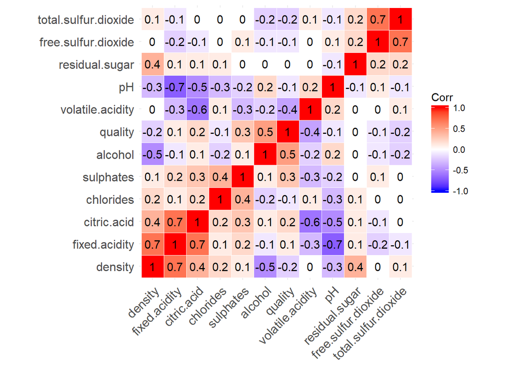

```
##                      fixed.acidity volatile.acidity citric.acid
## fixed.acidity                1.000           -0.256       0.672
## volatile.acidity            -0.256            1.000      -0.552
## citric.acid                  0.672           -0.552       1.000
## residual.sugar               0.115            0.002       0.144
## chlorides                    0.094            0.061       0.204
## free.sulfur.dioxide         -0.154           -0.011      -0.061
## total.sulfur.dioxide        -0.113            0.076       0.036
## density                      0.668            0.022       0.365
## pH                          -0.683            0.235      -0.542
## sulphates                    0.183           -0.261       0.313
## alcohol                     -0.062           -0.202       0.110
## quality                      0.124           -0.391       0.226
##                      residual.sugar chlorides free.sulfur.dioxide
## fixed.acidity                 0.115     0.094              -0.154
## volatile.acidity              0.002     0.061              -0.011
## citric.acid                   0.144     0.204              -0.061
## residual.sugar                1.000     0.056               0.187
## chlorides                     0.056     1.000               0.006
## free.sulfur.dioxide           0.187     0.006               1.000
## total.sulfur.dioxide          0.203     0.047               0.668
## density                       0.355     0.201              -0.022
## pH                           -0.086    -0.265               0.070
## sulphates                     0.006     0.371               0.052
## alcohol                       0.042    -0.221              -0.069
## quality                       0.014    -0.129              -0.051
##                      total.sulfur.dioxide density     pH sulphates alcohol
## fixed.acidity                      -0.113   0.668 -0.683     0.183  -0.062
## volatile.acidity                    0.076   0.022  0.235    -0.261  -0.202
## citric.acid                         0.036   0.365 -0.542     0.313   0.110
## residual.sugar                      0.203   0.355 -0.086     0.006   0.042
## chlorides                           0.047   0.201 -0.265     0.371  -0.221
## free.sulfur.dioxide                 0.668  -0.022  0.070     0.052  -0.069
## total.sulfur.dioxide                1.000   0.071 -0.066     0.043  -0.206
## density                             0.071   1.000 -0.342     0.149  -0.496
## pH                                 -0.066  -0.342  1.000    -0.197   0.206
## sulphates                           0.043   0.149 -0.197     1.000   0.094
## alcohol                            -0.206  -0.496  0.206     0.094   1.000
## quality                            -0.185  -0.175 -0.058     0.251   0.476
##                      quality
## fixed.acidity          0.124
## volatile.acidity      -0.391
## citric.acid            0.226
## residual.sugar         0.014
## chlorides             -0.129
## free.sulfur.dioxide   -0.051
## total.sulfur.dioxide  -0.185
## density               -0.175
## pH                    -0.058
## sulphates              0.251
## alcohol                0.476
## quality                1.000
```

I prepared the correlation matrix to see the relationships among various variables before selecting the important ones to continue the investigation. In particular I’d like to see how physicochemical variables influence quality. I am surprised to see there is no strong colleration between quality versus the input variables. The highest correlations are with alcohol level (0.476), volatile acidity (-0.391), sulfates (0.251) and citric acid (0.226).

Although I can understand high level of volatile acidity makes the wine sour and therefore unpleasant, I never thought that alcohol level have high colleration to quality.

Now I start to wonder about the factors that can influence the wine quality that are not captured by the variables in the dataset.For example, the grape type, grape ripping level, age of the vine, or the wine region could create some charactrs that we do not capture here (I am thinking about Bordeaux and Napa Valley here).

However, there are interesting relationships among the physicochemical variables. For example, fixed acidity collerate strongly with density (0.668) and pH (-0.683), and citric acid (0.672).

I also wondered how the outliers in the physicochemical properties impact wine quality? Will they create exceptional good wine or bad wine?

My next analysis will go deep into these interesting relationships.

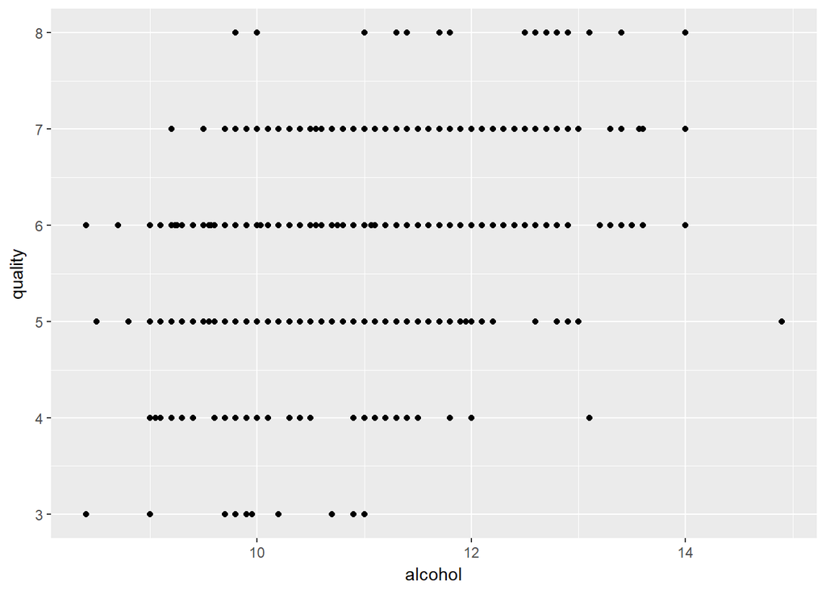

Overplotting problem to be fixed.

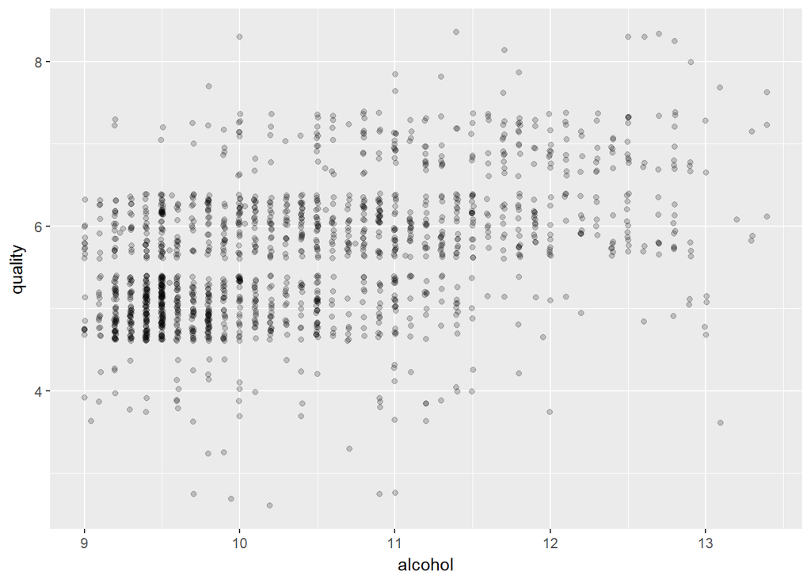

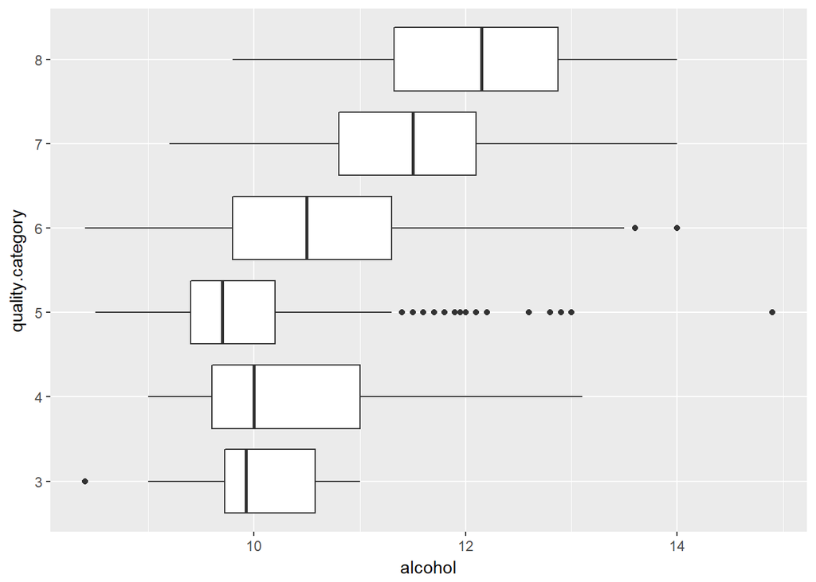

This box plot makes the relationship look clearer. The median alcohol levels of wine with quality index 7 and 8 are higher than those with lower quality.

However, there are many average quality sample with high alcohol content. What are other variables that can explain this?

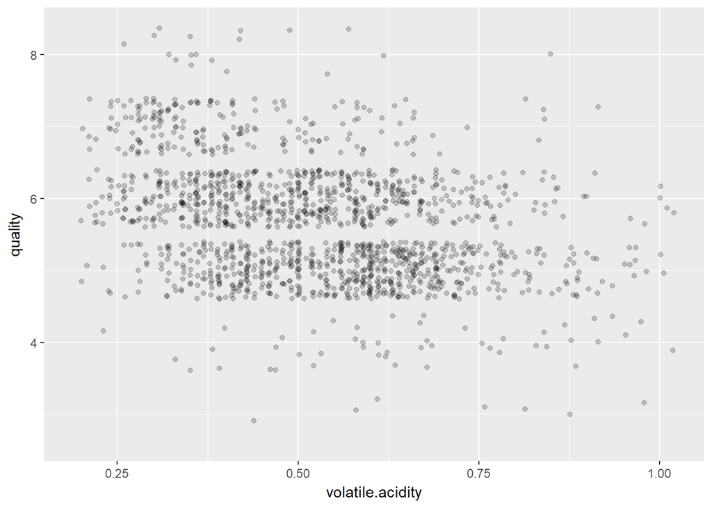

Low correlation between the two variables.

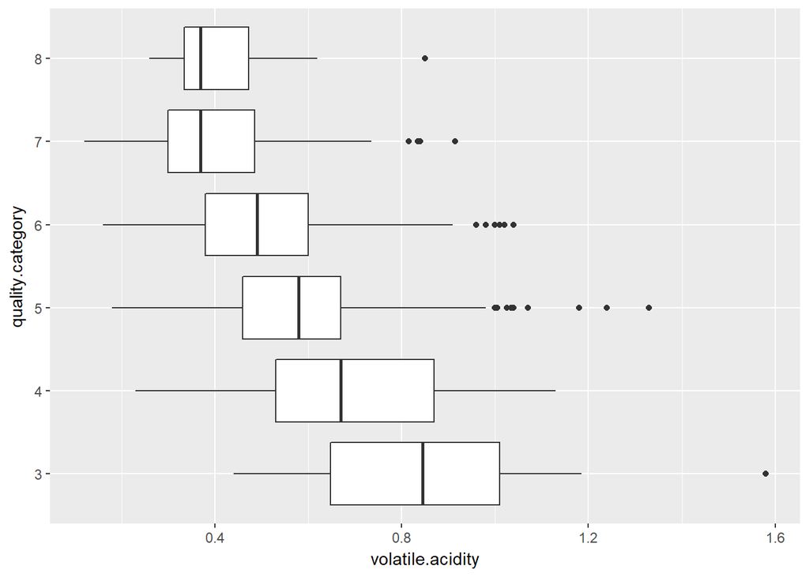

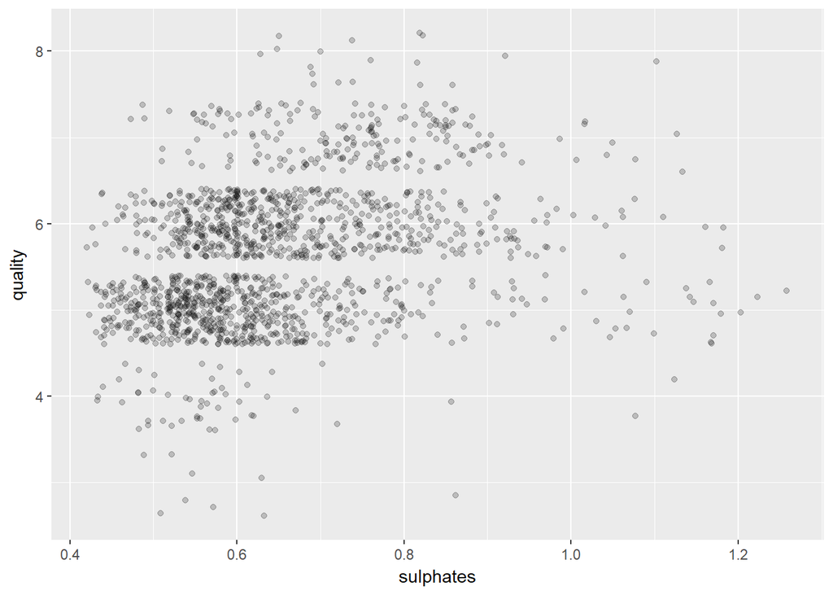

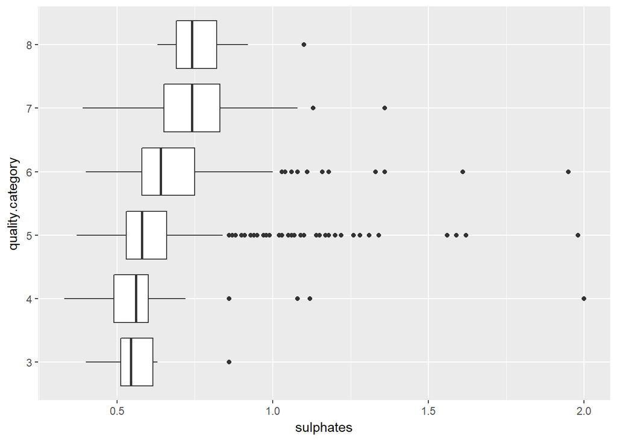

Sulphates level has a lower correlation with quality. In general, the higher sulphates, the higher the wine quality - up to a point. No good wine has sulphates level above 1.5g/l.

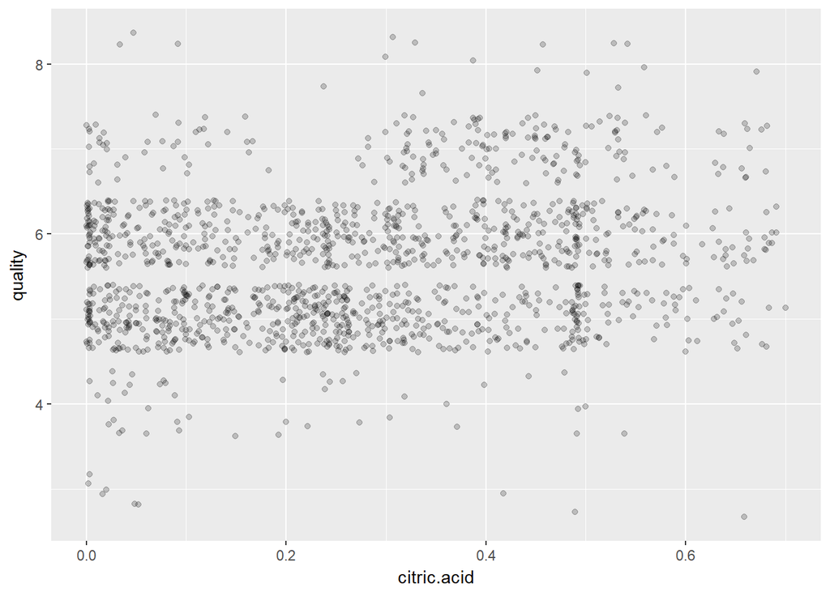

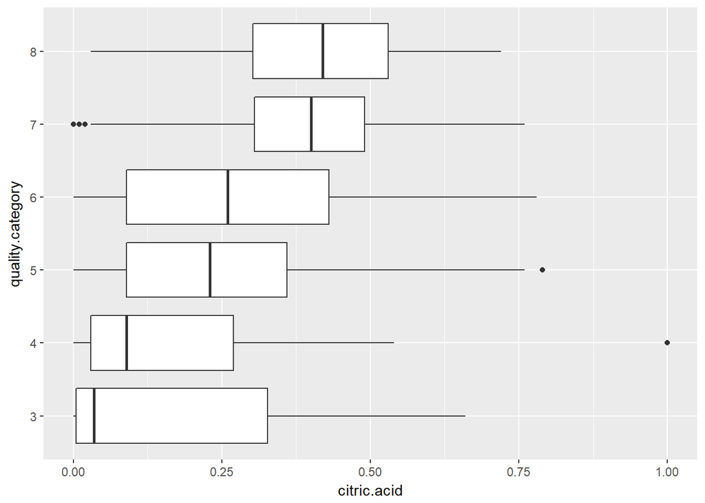

Similar to sulphates, citric acid has a weak correlation to quality, but overall higher quality wines have higher median citric acid.

Now I look into relationships among variables other than quality. There are interesting relationship among the physicochemical variables. For example, fixed acidity collerate strongly with density (0.668), pH (-0.683), and citric acid (0.672).

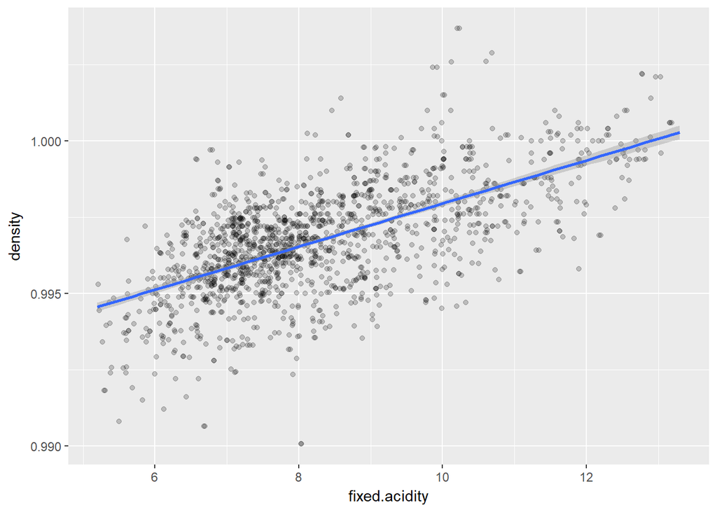

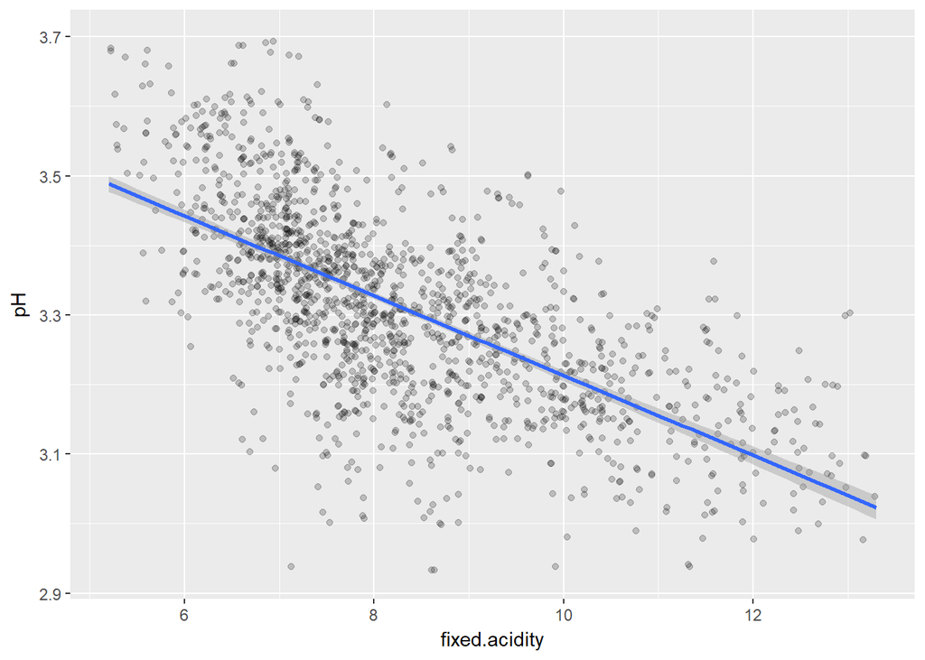

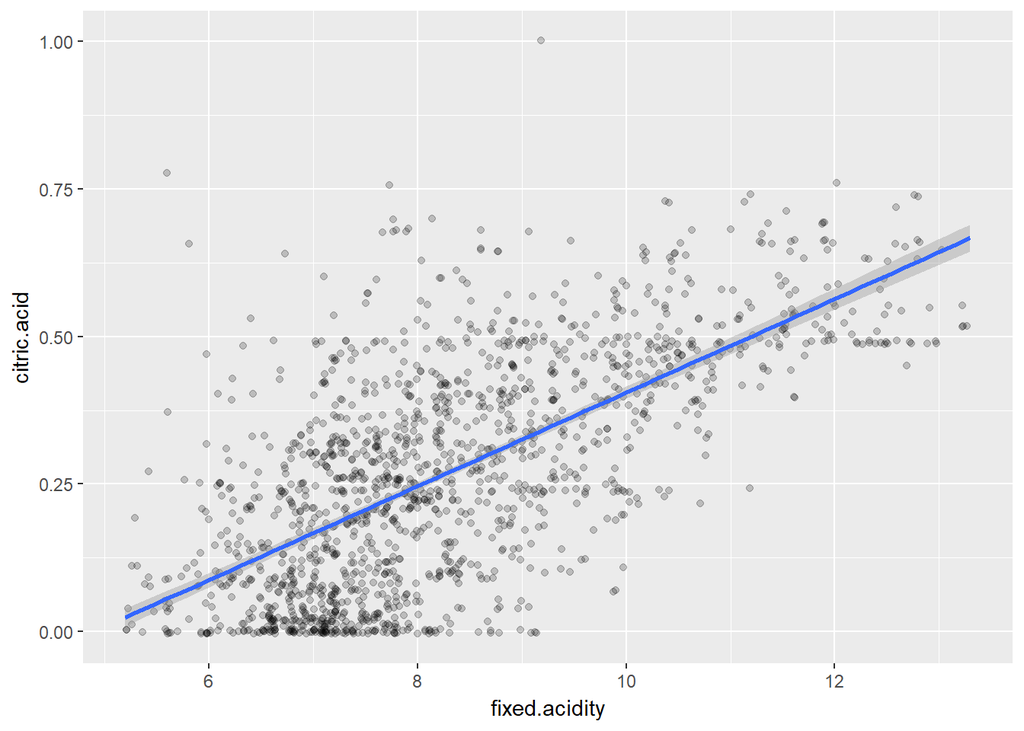

There is a correlation, but there are varied level of fixed acidity with citric acid level of 0g/l,

Now I want to understand how the outliers impact quality. I don’t like sweet wine, so I am checking for the sugar level outlier.

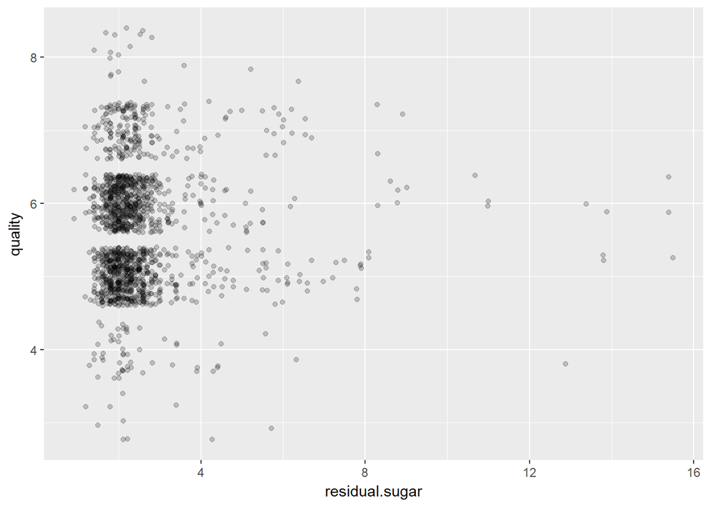

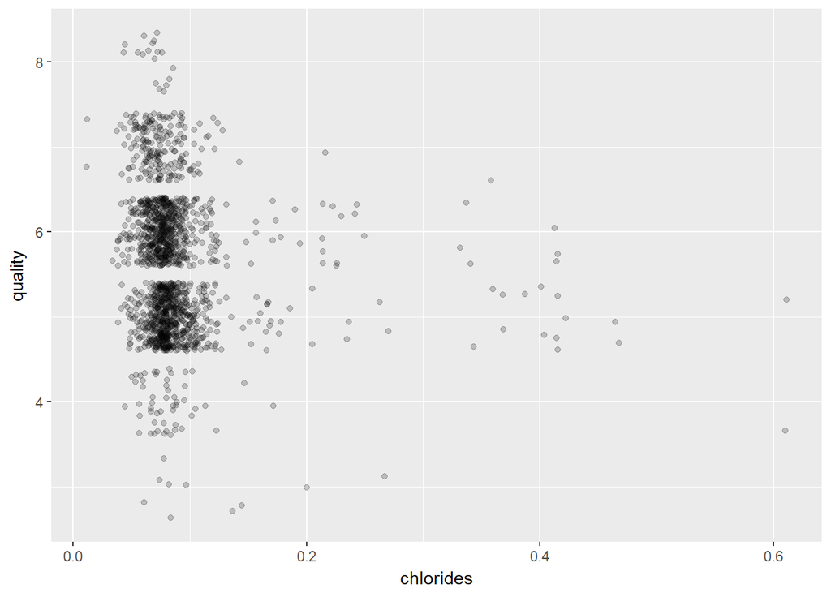

Same as residual sugar, exceptionally high chlorides does not make a good wine.

# Bivariate Analysis

### Talk about some of the relationships you observed in this part of the investigation. How did the feature(s) of interest vary with other features in the dataset?

There are weak correlation between quality and other physicochemical qualities. It seems that there are many factors could influence the quality of the wine, and perhaps the factors included in the dataset is not enough to predict the wine’s quality.

Having said that, there are some interesting relationships between wine quality and the physicochemical features. The strongest correlation (0.476) is with alcohol level, where the dataset suggests that high quality wine (7/8) have median alcohol level higher than 11% while low quality wine (3-5) have median alcohol content less than 11%.

On the other hand, the is a negative correlation between quality and volatile acidity. The box plot shows the higher the acidity, the lower the wine quality.

It is also interesting to note the sweet spot for sulphates. Good wines have sulphates level around 0.7-0.8g/l. Sulphates level outside this range seems to to result in bad or average wines. Similarly, the sweet spot for citric acid is around 0.3 -0.5 gram/liter.

### Did you observe any interesting relationships between the other features (not the main feature(s) of interest)?

There are interesting relationship among the physicochemical variables. For example, fixed acidity collerate strongly with density (0.668), pH (-0.683), and citric acid (0.672) .

### What was the strongest relationship you found?

Quality of wine is positively, although not strongly, correlated with alcohol content.